# Ford GoBike System Data Project

## by Ignatius Ebigwai

## Investigation Overview

> The aim of this investigation is to identify which demograph the GoBike service appeals to. This study is based on factors such as age, gender, user type, distance, and duration of rides.

## Dataset Overview

> This data set includes information about individual rides made in a bike-sharing system covering the greater San Francisco Bay area from 1st Feb 2019 to 1st March 2019. The dataset is a public dataset and can be found at https://www.google.com/url?q=https://www.fordgobike.com/system-data&sa=D&ust=1554484977399000 with feature such as bike_id, start and end station, start and end station Id, start and end coordinates etc.

### Investigation Period

The period under investigation is one month, that is February 2019

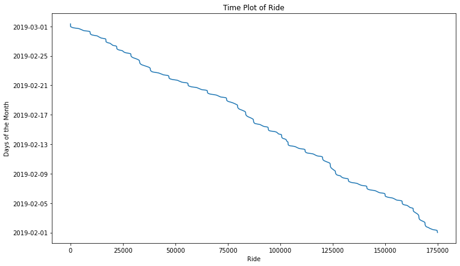

### Week days with Most Rides

Thursdays, Tuesdays and Wednesdays respectively are the week days with the most rides, accounting for over 52% of rides. While weekends (Saturday and Sundays ) has the least rides

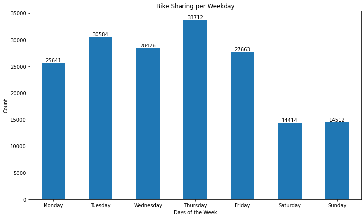

### Age Distribution

Age distribution is unimodal and we see more riders within the ages of 25 and 45 with the most being between 30 and 40

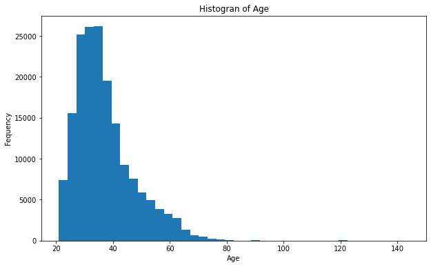

### Duration Distribution

Duration distributin is a normal distribution the most duration between 200 and 1000 seconds

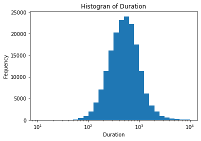

### User Types

Subscribed users are over 150,000 which is over 85% of the riders during the period under review

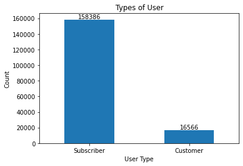

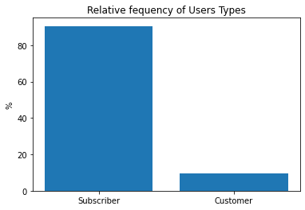

### Riders Gender Percentage

Males rider are over 130,000 which is about 75% of riders in the dataset

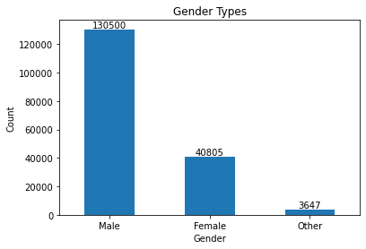

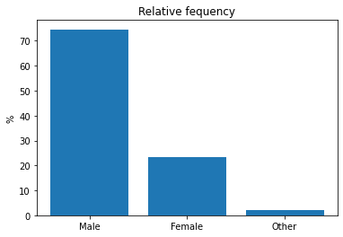

### Shared Rides

Unshared riders were relatiely higher (over 85%) compared with shared rides.

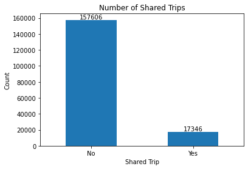

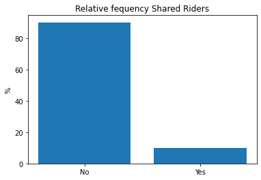

### Relationship Between Age and Gender

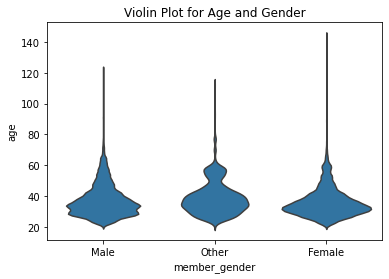

### Relationship with Age and Shared Trips

Younger riders shared their trips more compared to older riders

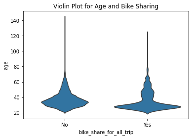

### Relations Between Age and Ride Distance

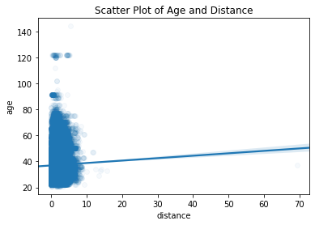

### Relations Between Age and Ride Duration

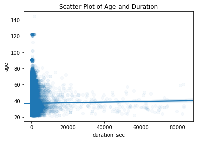

### Relationship Beyween Age, Distance and Duration of Rides

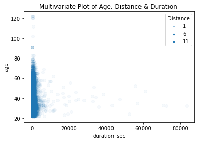